# Fundamentals of Data Analysis

Final Group Project - Group 4

30 Sep 2022

```r
library(knitr)
hook_output = knit_hooks$get('output')
knit_hooks$set(output = function(x, options) {
  # this hook is used only when the linewidth option is not NULL
  if (!is.null(n <- options$linewidth)) {
    x = xfun::split_lines(x)
    # any lines wider than n should be wrapped
    if (any(nchar(x) > n)) x = strwrap(x, width = n)
    x = paste(x, collapse = '\n')
  }
  hook_output(x, options)
})
```

# 1 R Project

## 1.1 Exploratory Data Analysis

```r
listings <- vroom("http://data.insideairbnb.com/italy/emilia-romagna/bologna/2022-06-11/data/listings.csv.gz")%>%
      #drop variables that contain 'scrape' in their column name
  select(- contains("scrape"))

listings <- listings %>%
  mutate(price = parse_number(price))
```

```
## Rows: 3,685
## Columns: 71
## $ id                                           <dbl> 42196, 1496752, 1538460, …
## $ listing_url                                  <chr> "https://www.airbnb.com/r…
## $ name                                         <chr> "50 sm Studio in the hist…
## $ description                                  <chr> "<b>The space</b><br />Re…
## $ neighborhood_overview                        <chr> NA, "It's a great locatio…
## $ picture_url                                  <chr> "https://a0.muscache.com/…
## $ host_id                                      <dbl> 184487, 1373203, 4664996,…
## $ host_url                                     <chr> "https://www.airbnb.com/u…
## $ host_name                                    <chr> "Carlo", "Ludovica", "Vie…
## $ host_since                                   <date> 2010-07-29, 2011-11-05, …
## $ host_location                                <chr> "Bologna, Emilia-Romagna,…
## $ host_about                                   <chr> "Born in Bologna, raised …
## $ host_response_time                           <chr> "within an hour", "within…
```

[output cut: 58 more lines]

Data summary

| Name | listings |
| --- | --- |
| Number of rows | 3685 |
| Number of columns | 71 |
| _______________________ |  |
| Column type frequency: |  |
| character | 23 |
| Date | 3 |
| logical | 8 |
| numeric | 37 |
| ________________________ |  |
| Group variables | None |

**Variable type: character**

| skim_variable | n_missing | complete_rate | min | max | empty | n_unique | whitespace |
| --- | --- | --- | --- | --- | --- | --- | --- |
| listing_url | 0 | 1.00 | 34 | 47 | 0 | 3685 | 0 |
| name | 0 | 1.00 | 4 | 250 | 0 | 3637 | 0 |
| description | 76 | 0.98 | 12 | 1000 | 0 | 3497 | 0 |
| neighborhood_overview | 1369 | 0.63 | 1 | 1000 | 0 | 1908 | 0 |
| picture_url | 0 | 1.00 | 61 | 126 | 0 | 3636 | 0 |
| host_url | 0 | 1.00 | 39 | 43 | 0 | 2097 | 0 |
| host_name | 0 | 1.00 | 1 | 35 | 0 | 780 | 0 |
| host_location | 6 | 1.00 | 2 | 51 | 0 | 175 | 0 |
| host_about | 1807 | 0.51 | 1 | 6044 | 0 | 942 | 0 |
| host_response_time | 0 | 1.00 | 3 | 18 | 0 | 5 | 0 |
| host_response_rate | 0 | 1.00 | 2 | 4 | 0 | 46 | 0 |
| host_acceptance_rate | 0 | 1.00 | 2 | 4 | 0 | 86 | 0 |
| host_thumbnail_url | 0 | 1.00 | 55 | 106 | 0 | 2072 | 0 |
| host_picture_url | 0 | 1.00 | 57 | 109 | 0 | 2072 | 0 |
| host_neighbourhood | 3611 | 0.02 | 4 | 23 | 0 | 15 | 0 |
| host_verifications | 0 | 1.00 | 2 | 32 | 0 | 6 | 0 |
| neighbourhood | 1369 | 0.63 | 5 | 45 | 0 | 32 | 0 |
| neighbourhood_cleansed | 0 | 1.00 | 6 | 23 | 0 | 6 | 0 |
| property_type | 0 | 1.00 | 4 | 34 | 0 | 41 | 0 |
| room_type | 0 | 1.00 | 10 | 15 | 0 | 4 | 0 |
| bathrooms_text | 5 | 1.00 | 6 | 17 | 0 | 22 | 0 |
| amenities | 0 | 1.00 | 8 | 1437 | 0 | 3524 | 0 |
| license | 3473 | 0.06 | 1 | 85 | 0 | 185 | 0 |

**Variable type: Date**

| skim_variable | n_missing | complete_rate | min | max | median | n_unique |
| --- | --- | --- | --- | --- | --- | --- |
| host_since | 0 | 1.00 | 2009-09-14 | 2022-06-07 | 2016-09-07 | 1540 |
| first_review | 409 | 0.89 | 2010-09-27 | 2022-06-10 | 2019-03-31 | 1591 |
| last_review | 409 | 0.89 | 2013-06-11 | 2022-06-10 | 2022-05-11 | 720 |

**Variable type: logical**

| skim_variable | n_missing | complete_rate | mean | count |
| --- | --- | --- | --- | --- |
| host_is_superhost | 0 | 1 | 0.29 | FAL: 2622, TRU: 1063 |
| host_has_profile_pic | 0 | 1 | 0.99 | TRU: 3651, FAL: 34 |
| host_identity_verified | 0 | 1 | 0.86 | TRU: 3176, FAL: 509 |
| neighbourhood_group_cleansed | 3685 | 0 | NaN | : |
| bathrooms | 3685 | 0 | NaN | : |
| calendar_updated | 3685 | 0 | NaN | : |
| has_availability | 0 | 1 | 1.00 | TRU: 3682, FAL: 3 |
| instant_bookable | 0 | 1 | 0.56 | TRU: 2054, FAL: 1631 |

**Variable type: numeric**

| skim_variable | n_missing | complete_rate | mean | sd | p0 | p25 | p50 | p75 | p100 | hist |
| --- | --- | --- | --- | --- | --- | --- | --- | --- | --- | --- |
| id | 0 | 1.00 | 6.19e+16 | 1.83e+17 | 42196.00 | 1.98e+07 | 3.30e+07 | 4.79e+07 | 6.46e+17 | ▇▁▁▁▁ |
| host_id | 0 | 1.00 | 1.32e+08 | 1.26e+08 | 38468.00 | 2.50e+07 | 9.32e+07 | 2.15e+08 | 4.63e+08 | ▇▃▂▁▁ |
| host_listings_count | 0 | 1.00 | 3.08e+01 | 1.45e+02 | 0.00 | 1.00e+00 | 2.00e+00 | 5.00e+00 | 1.48e+03 | ▇▁▁▁▁ |
| host_total_listings_count | 0 | 1.00 | 3.08e+01 | 1.45e+02 | 0.00 | 1.00e+00 | 2.00e+00 | 5.00e+00 | 1.48e+03 | ▇▁▁▁▁ |
| latitude | 0 | 1.00 | 4.45e+01 | 1.00e-02 | 44.42 | 4.45e+01 | 4.45e+01 | 4.45e+01 | 4.46e+01 | ▁▁▇▁▁ |
| longitude | 0 | 1.00 | 1.13e+01 | 2.00e-02 | 11.22 | 1.13e+01 | 1.13e+01 | 1.13e+01 | 1.14e+01 | ▁▁▇▂▁ |
| accommodates | 0 | 1.00 | 3.31e+00 | 1.65e+00 | 1.00 | 2.00e+00 | 3.00e+00 | 4.00e+00 | 1.60e+01 | ▇▁▁▁▁ |
| bedrooms | 164 | 0.96 | 1.30e+00 | 6.60e-01 | 1.00 | 1.00e+00 | 1.00e+00 | 1.00e+00 | 1.00e+01 | ▇▁▁▁▁ |
| beds | 44 | 0.99 | 2.03e+00 | 1.33e+00 | 1.00 | 1.00e+00 | 2.00e+00 | 2.00e+00 | 2.00e+01 | ▇▁▁▁▁ |
| price | 0 | 1.00 | 1.35e+02 | 4.75e+02 | 9.00 | 6.00e+01 | 8.50e+01 | 1.26e+02 | 1.60e+04 | ▇▁▁▁▁ |
| minimum_nights | 0 | 1.00 | 2.84e+00 | 1.08e+01 | 1.00 | 1.00e+00 | 2.00e+00 | 2.00e+00 | 3.65e+02 | ▇▁▁▁▁ |
| maximum_nights | 0 | 1.00 | 4.79e+02 | 5.04e+02 | 1.00 | 2.90e+01 | 1.80e+02 | 1.12e+03 | 1.12e+03 | ▇▂▁▁▆ |
| minimum_minimum_nights | 0 | 1.00 | 2.71e+00 | 1.08e+01 | 1.00 | 1.00e+00 | 2.00e+00 | 2.00e+00 | 3.65e+02 | ▇▁▁▁▁ |
| maximum_minimum_nights | 0 | 1.00 | 5.04e+00 | 1.44e+01 | 1.00 | 1.00e+00 | 2.00e+00 | 4.00e+00 | 3.65e+02 | ▇▁▁▁▁ |
| minimum_maximum_nights | 0 | 1.00 | 6.33e+02 | 5.16e+02 | 1.00 | 3.00e+01 | 1.11e+03 | 1.12e+03 | 1.12e+03 | ▆▂▁▁▇ |
| maximum_maximum_nights | 0 | 1.00 | 6.75e+02 | 5.07e+02 | 1.00 | 4.50e+01 | 1.12e+03 | 1.12e+03 | 1.12e+03 | ▅▂▁▁▇ |
| minimum_nights_avg_ntm | 0 | 1.00 | 3.51e+00 | 1.13e+01 | 1.00 | 1.00e+00 | 2.00e+00 | 3.00e+00 | 3.65e+02 | ▇▁▁▁▁ |
| maximum_nights_avg_ntm | 0 | 1.00 | 6.67e+02 | 5.06e+02 | 1.00 | 4.00e+01 | 1.12e+03 | 1.12e+03 | 1.12e+03 | ▅▂▁▁▇ |
| availability_30 | 0 | 1.00 | 6.38e+00 | 7.77e+00 | 0.00 | 0.00e+00 | 3.00e+00 | 1.00e+01 | 3.00e+01 | ▇▂▁▁▁ |
| availability_60 | 0 | 1.00 | 1.83e+01 | 1.76e+01 | 0.00 | 1.00e+00 | 1.30e+01 | 3.10e+01 | 6.00e+01 | ▇▃▂▂▁ |
| availability_90 | 0 | 1.00 | 3.27e+01 | 2.79e+01 | 0.00 | 4.00e+00 | 3.00e+01 | 5.60e+01 | 9.00e+01 | ▇▃▃▃▂ |
| availability_365 | 0 | 1.00 | 1.38e+02 | 1.17e+02 | 0.00 | 3.00e+01 | 1.20e+02 | 2.34e+02 | 3.65e+02 | ▇▃▃▂▃ |
| number_of_reviews | 0 | 1.00 | 4.30e+01 | 7.41e+01 | 0.00 | 3.00e+00 | 1.50e+01 | 4.80e+01 | 8.12e+02 | ▇▁▁▁▁ |
| number_of_reviews_ltm | 0 | 1.00 | 1.13e+01 | 1.75e+01 | 0.00 | 0.00e+00 | 4.00e+00 | 1.40e+01 | 1.48e+02 | ▇▁▁▁▁ |
| number_of_reviews_l30d | 0 | 1.00 | 1.35e+00 | 2.14e+00 | 0.00 | 0.00e+00 | 0.00e+00 | 2.00e+00 | 1.40e+01 | ▇▂▁▁▁ |
| review_scores_rating | 409 | 0.89 | 4.73e+00 | 4.30e-01 | 0.00 | 4.67e+00 | 4.83e+00 | 4.95e+00 | 5.00e+00 | ▁▁▁▁▇ |
| review_scores_accuracy | 420 | 0.89 | 4.79e+00 | 3.40e-01 | 0.00 | 4.74e+00 | 4.88e+00 | 4.98e+00 | 5.00e+00 | ▁▁▁▁▇ |
| review_scores_cleanliness | 420 | 0.89 | 4.77e+00 | 3.50e-01 | 0.00 | 4.70e+00 | 4.88e+00 | 5.00e+00 | 5.00e+00 | ▁▁▁▁▇ |
| review_scores_checkin | 420 | 0.89 | 4.86e+00 | 2.80e-01 | 0.00 | 4.83e+00 | 4.94e+00 | 5.00e+00 | 5.00e+00 | ▁▁▁▁▇ |
| review_scores_communication | 420 | 0.89 | 4.85e+00 | 3.10e-01 | 0.00 | 4.83e+00 | 4.94e+00 | 5.00e+00 | 5.00e+00 | ▁▁▁▁▇ |
| review_scores_location | 420 | 0.89 | 4.76e+00 | 3.20e-01 | 0.00 | 4.65e+00 | 4.85e+00 | 4.98e+00 | 5.00e+00 | ▁▁▁▁▇ |
| review_scores_value | 420 | 0.89 | 4.65e+00 | 3.80e-01 | 0.00 | 4.54e+00 | 4.74e+00 | 4.86e+00 | 5.00e+00 | ▁▁▁▁▇ |
| calculated_host_listings_count | 0 | 1.00 | 8.03e+00 | 1.65e+01 | 1.00 | 1.00e+00 | 2.00e+00 | 5.00e+00 | 8.20e+01 | ▇▁▁▁▁ |
| calculated_host_listings_count_entire_homes | 0 | 1.00 | 7.02e+00 | 1.65e+01 | 0.00 | 1.00e+00 | 1.00e+00 | 3.00e+00 | 8.10e+01 | ▇▁▁▁▁ |
| calculated_host_listings_count_private_rooms | 0 | 1.00 | 8.70e-01 | 1.65e+00 | 0.00 | 0.00e+00 | 0.00e+00 | 1.00e+00 | 1.10e+01 | ▇▁▁▁▁ |
| calculated_host_listings_count_shared_rooms | 0 | 1.00 | 2.00e-02 | 2.40e-01 | 0.00 | 0.00e+00 | 0.00e+00 | 0.00e+00 | 5.00e+00 | ▇▁▁▁▁ |
| reviews_per_month | 409 | 0.89 | 1.40e+00 | 1.60e+00 | 0.01 | 3.10e-01 | 8.80e-01 | 1.90e+00 | 1.52e+01 | ▇▁▁▁▁ |

How many variables/columns?

```r
ncol(listings)
```

```
## [1] 71
```

How many rows/observations?

```r
nrow(listings)
```

```
## [1] 3685
```

Which variables are numbers?

```r
print(paste("List of the variables that are numbers"))
```

```
## [1] "List of the variables that are numbers"
```

```r
i=1
for(i in 1:ncol(listings)) {       # for-loop over columns
   if (is.numeric(listings[[i]]) == TRUE)
   {
    print(colnames(listings[i]))
  }
 }
```

```
## [1] "id"
## [1] "host_id"
## [1] "host_listings_count"
## [1] "host_total_listings_count"
## [1] "latitude"
## [1] "longitude"
## [1] "accommodates"
## [1] "bedrooms"
## [1] "beds"
## [1] "price"
## [1] "minimum_nights"
## [1] "maximum_nights"
## [1] "minimum_minimum_nights"
## [1] "maximum_minimum_nights"
## [1] "minimum_maximum_nights"
```

[output cut: 22 more lines]

Which are categorical or factor variables (numeric or character variables with variables that have a fixed and known set of possible values)?

```r
maxElements = 10

result <- apply(listings, 2, function(x) length(unique(x)))

print(paste("List of the variables with less than ",maxElements, "elements"))
```

```
## [1] "List of the variables with less than  10 elements"
```

```r
for(i in 1:ncol(listings)) {       # for-loop over columns
 if(result[colnames(listings)[i]] < maxElements)
 {
   print(colnames(listings)[i])
 }
}
```

[output not shown]

What are the correlations between variables? Does each scatterplot support a linear relationship between variables? Do any of the correlations appear to be conditional on the value of a categorical variable?

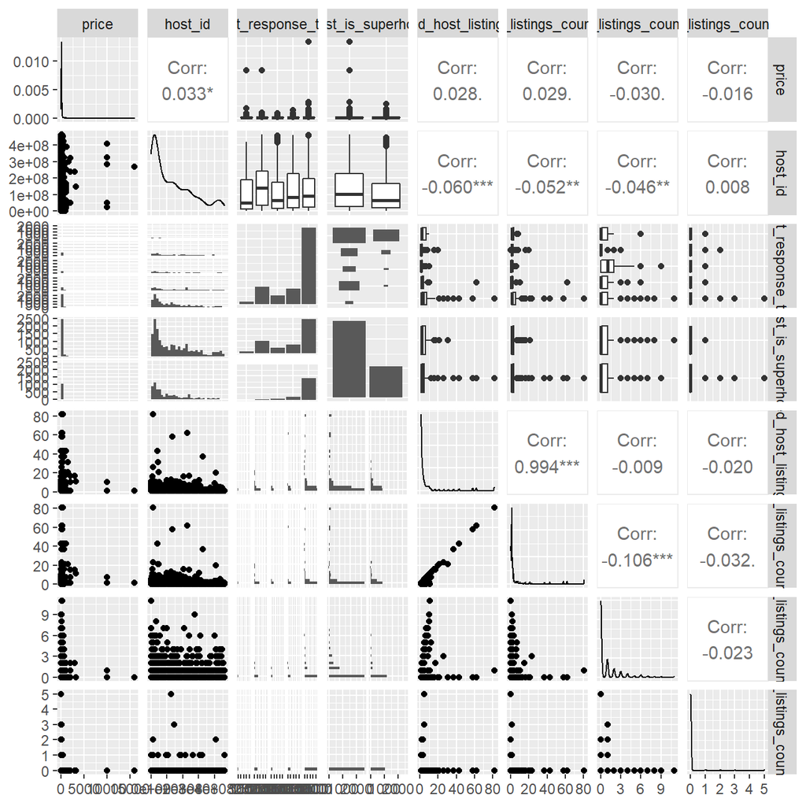

```r
# exploring correlations with type of hosts
listings%>%
  select(price, host_id, host_response_time, host_is_superhost, calculated_host_listings_count, calculated_host_listings_count_entire_homes, calculated_host_listings_count_private_rooms, calculated_host_listings_count_shared_rooms)%>%
  ggpairs(alpha = 0.3)
```

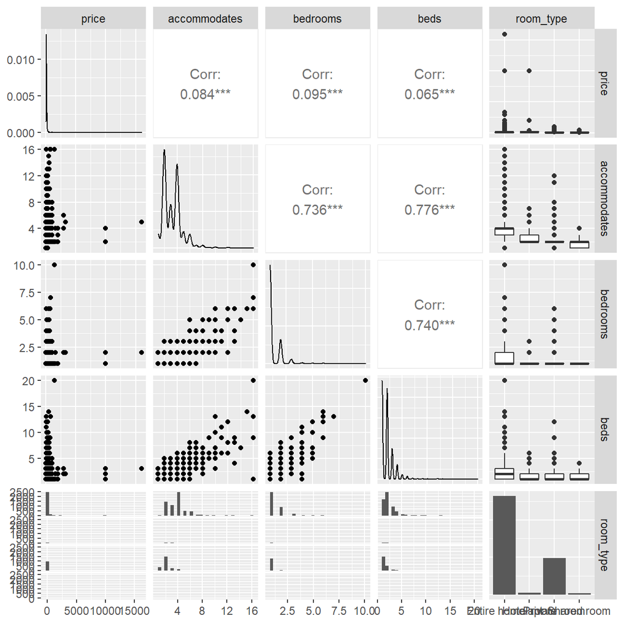

```r
# exploring correlations with parameters of house
listings%>%
  select(price, accommodates, bedrooms, beds, room_type)%>%
  ggpairs(alpha = 0.3)
```

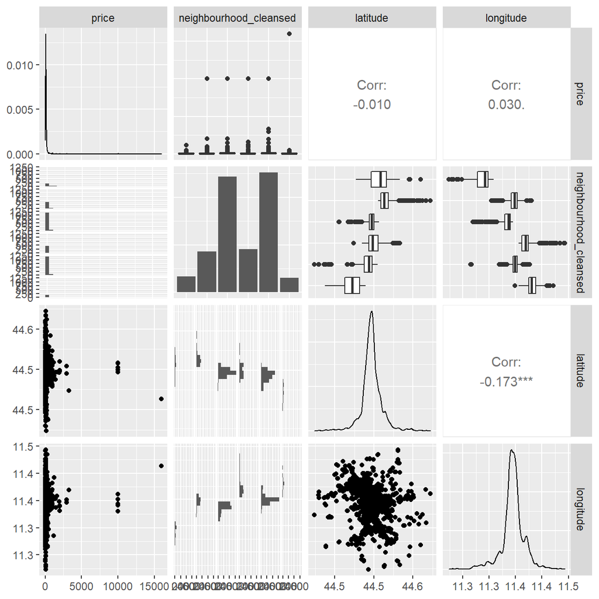

```r
#exploring correlations with location
listings%>%
  select(price, neighbourhood_cleansed, latitude, longitude)%>%
  ggpairs(alpha = 0.3)
```

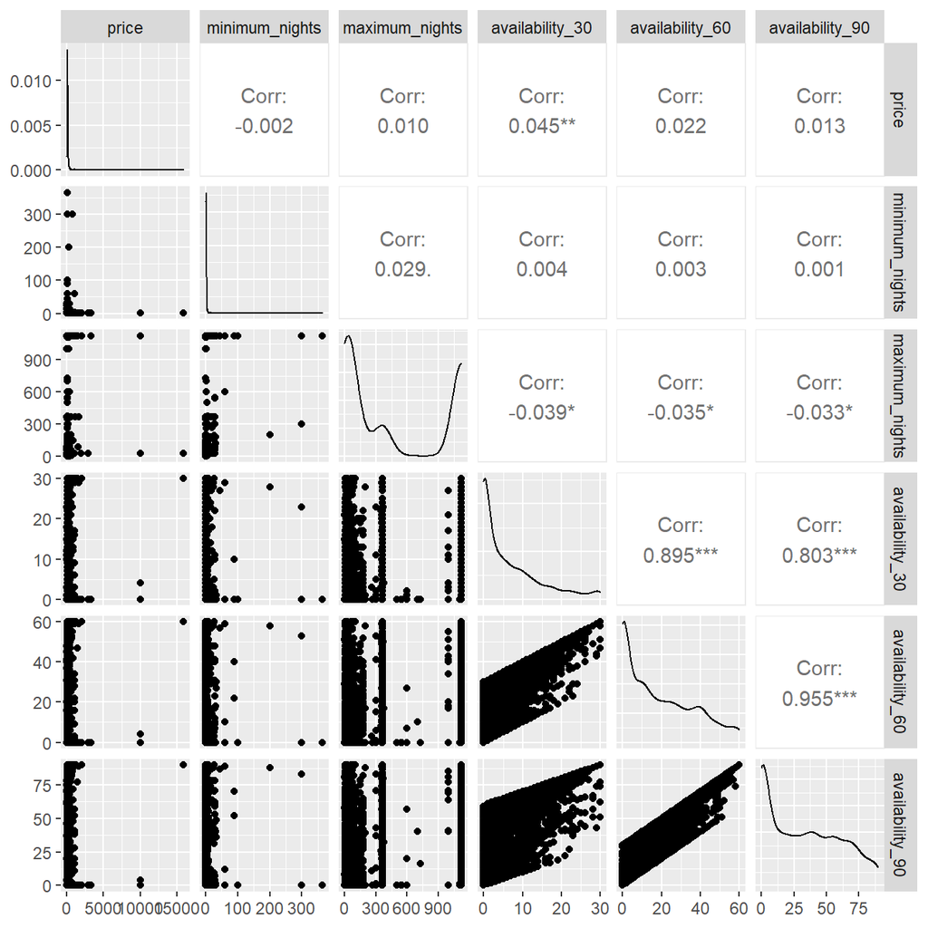

```r
# exploring correlations with availability
listings%>%
  select(price, minimum_nights, maximum_nights, availability_30, availability_60, availability_90)%>%
  ggpairs(alpha = 0.3)
```

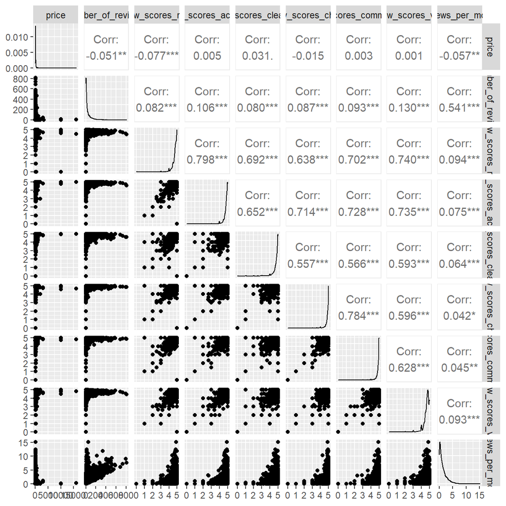

```r
# exploring correlations with reviews
listings%>%
  select(price, number_of_reviews, review_scores_rating, review_scores_accuracy, review_scores_cleanliness, review_scores_checkin, review_scores_communication, review_scores_value, reviews_per_month)%>%
  ggpairs(alpha = 0.3)
```

```r
listings %>%
  filter(number_of_reviews>50) %>%
  group_by(neighbourhood_cleansed) %>%
  summarise(medianPrice = median(price),
            medianRate = median(review_scores_rating, na.rm = TRUE),
            medianBedroom = median(bedrooms, na.rm = TRUE),
            medianMinimumNights = median(minimum_minimum_nights,na.rm = TRUE))
```

| neighbourhood_cleansed | medianPrice | medianRate | medianBedroom | medianMinimumNights |
| --- | --- | --- | --- | --- |
| Borgo Panigale - Reno | 55.5 | 4.83 | 1 | 1 |
| Navile | 58 | 4.82 | 1 | 1 |
| Porto - Saragozza | 76 | 4.82 | 1 | 2 |
| San Donato - San Vitale | 60 | 4.82 | 1 | 2 |
| Santo Stefano | 79.5 | 4.84 | 1 | 2 |
| Savena | 55 | 4.87 | 1 | 1 |

```r
listings %>%
  filter(number_of_reviews>50) %>%
  group_by(property_type) %>%
  summarise(medianPrice = median(price),
            medianRate = median(review_scores_rating, na.rm = TRUE),
            medianBedroom = median(bedrooms, na.rm = TRUE),
            medianMinimumNights = median(minimum_minimum_nights,na.rm = TRUE),
            totalAccomodations = count(property_type)) %>%
  filter(totalAccomodations > 5)
```

| property_type | medianPrice | medianRate | medianBedroom | medianMinimumNights | totalAccomodations |
| --- | --- | --- | --- | --- | --- |
| Entire condo | 91.5 | 4.83 | 1 | 1 | 90 |
| Entire home | 100 | 4.81 | 1 | 1 | 24 |
| Entire loft | 81.5 | 4.89 | 1 | 2 | 34 |
| Entire rental unit | 78 | 4.84 | 1 | 2 | 541 |
| Entire vacation home | 104 | 4.86 | 1 | 1 | 11 |
| Private room in bed and breakfast | 51 | 4.83 | 1 | 1 | 26 |
| Private room in condo | 41 | 4.83 | 1 | 1 | 39 |
| Private room in home | 43 | 4.85 | 1 | 1.5 | 6 |
| Private room in rental unit | 40.5 | 4.8 | 1 | 1 | 100 |
| Shared room in rental unit | 16 | 4.5 | 1 | 1 | 6 |

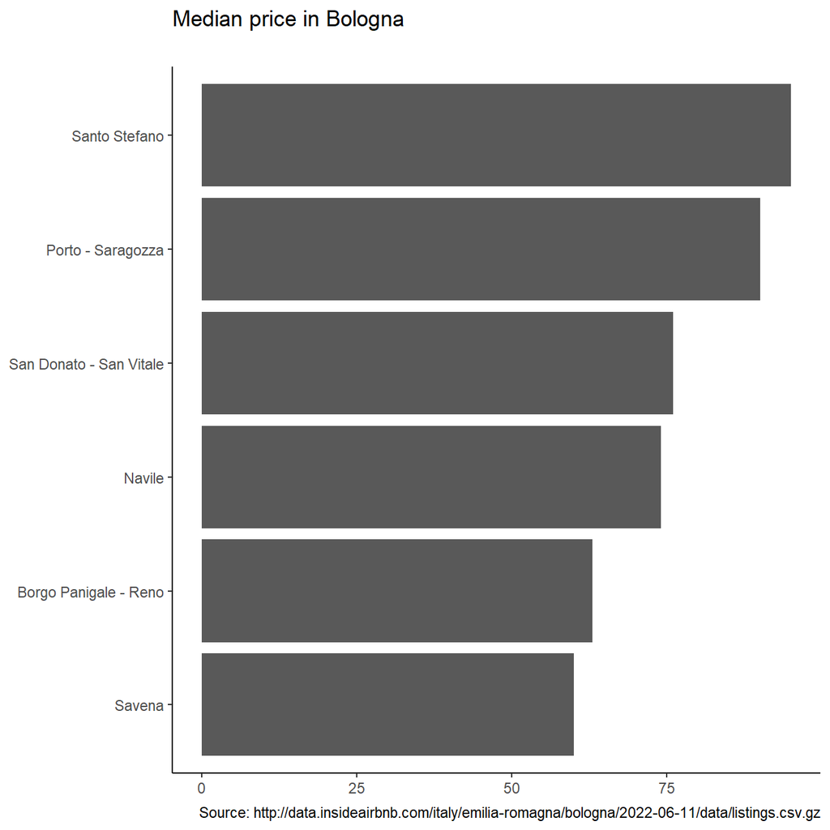

```r
listings %>%
  group_by(neighbourhood_cleansed) %>%
  summarise(medianPrice = median(price)) %>%
  mutate(neighbourhood_cleansed = fct_reorder(neighbourhood_cleansed, medianPrice)) %>%
  ggplot(aes(x=medianPrice,y=neighbourhood_cleansed)) +
  geom_col() +
  theme_classic() +
  labs(title = "Median price in Bologna",
        subtitle = "",
        caption = "Source: http://data.insideairbnb.com/italy/emilia-romagna/bologna/2022-06-11/data/listings.csv.gz") +
  theme(plot.caption = element_text(hjust= 1),
        axis.title.x = element_blank(),
        axis.title.y = element_blank())
```

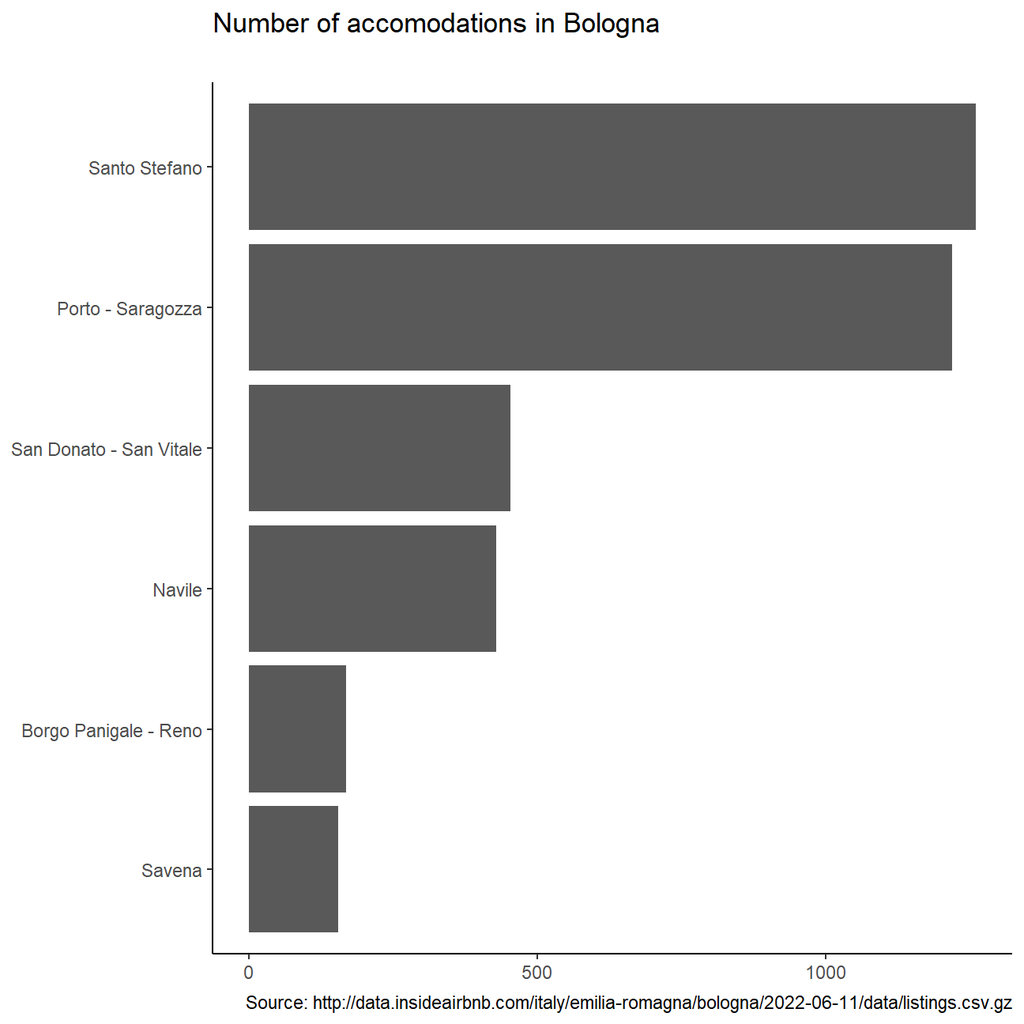

```r
listings %>%
  group_by(neighbourhood_cleansed) %>%
  summarise(totalAccomodation = count(neighbourhood_cleansed)) %>%
  mutate(neighbourhood_cleansed = fct_reorder(neighbourhood_cleansed, totalAccomodation)) %>%
  ggplot(aes(x=totalAccomodation,y=neighbourhood_cleansed)) +
  geom_col() +
  theme_classic() +
  labs(title = "Number of accomodations in Bologna",
        subtitle = "",
        caption = "Source: http://data.insideairbnb.com/italy/emilia-romagna/bologna/2022-06-11/data/listings.csv.gz") +
  theme(plot.caption = element_text(hjust= 1),
        axis.title.x = element_blank(), #
        axis.title.y = element_blank())
```

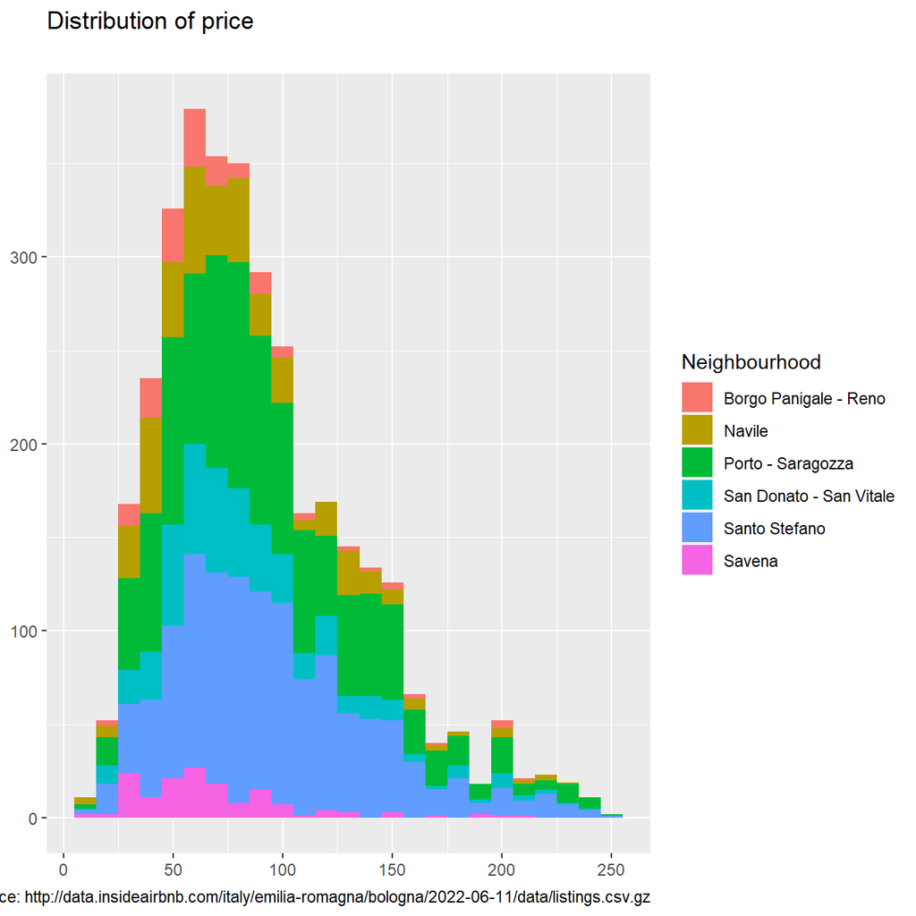

```r
listings %>%
  filter(price<250) %>%
  ggplot(aes(price,fill=neighbourhood_cleansed)) +
  geom_histogram(binwidth = 10) +
  labs(title = "Distribution of price",
        subtitle = "",
        caption = "Source: http://data.insideairbnb.com/italy/emilia-romagna/bologna/2022-06-11/data/listings.csv.gz") +
  theme(plot.caption = element_text(hjust= 1),
        axis.title.x = element_blank(),
        axis.title.y = element_blank()) +
  scale_fill_discrete(name = "Neighbourhood")
```

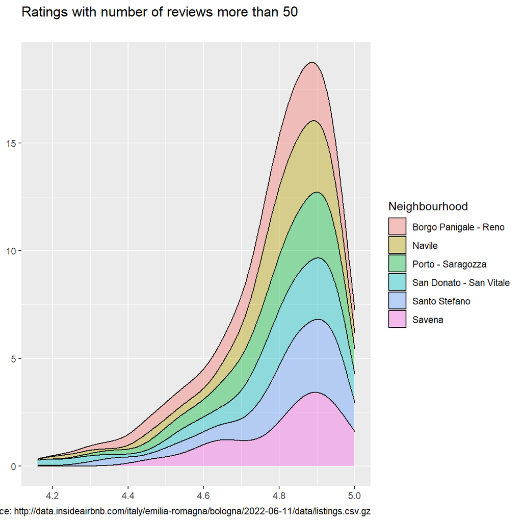

```r
listings %>%
  filter(number_of_reviews>50) %>%
  ggplot(aes(review_scores_rating, fill = neighbourhood_cleansed)) +
  geom_density(position = "stack", alpha = 0.4) +
   labs(title = "Ratings with number of reviews more than 50",
        subtitle = "",
        caption = "Source: http://data.insideairbnb.com/italy/emilia-romagna/bologna/2022-06-11/data/listings.csv.gz") +
  theme(plot.caption = element_text(hjust= 1),
        axis.title.x = element_blank(),
        axis.title.y = element_blank()) +
  scale_fill_discrete(name = "Neighbourhood")
```

*There are the following correlations (>0.5) among variables:*

- *calculated_host_listings_count, calculated_host_listings_count_entire_homes,*
- *bedrooms, beds, accommodates,*
- *availability_30, availability_60, availability_90,*
- *review_scores_rating, review_scores_accuracy, review_scores_cleanliness, review_scores_checkin, review_scores_communication, review_scores_value,*

*There are the following linear correlations:*

- *calculated_host_listings_count, calculated_host_listings_count_entire_homes*

## 1.2 Handling missing values (NAs)

Airbnb is most commonly used for travel purposes, i.e., as an alternative to traditional hotels. We only want to include listings in our regression analysis that are intended for travel purposes:

Next, we look at the variable property_type. We can use the count function to determine how many categories there are their frequency. What are the top 4 most common property types? What proportion of the total listings do they make up?

```r
listings %>%
  group_by(property_type) %>%
  summarise(countType = count(property_type)) %>%
  mutate(percentage = percent(countType/sum(countType))) %>%
  slice_max(order_by = countType, n=4)
```

| property_type | countType | percentage |
| --- | --- | --- |
| Entire rental unit | 1772 | 0.480868385345997 |
| Entire condo | 577 | 0.156580732700136 |
| Private room in rental unit | 430 | 0.116689280868385 |
| Private room in condo | 244 | 0.0662143826322931 |

Since the vast majority of the observations in the data are one of the top four or five property types, we would like to create a simplified version of property_type variable that has 5 categories: the top four categories and Other. Fill in the code below to create prop_type_simplified.

```r
listings <- listings %>%
  mutate(prop_type_simplified = case_when(
    property_type %in% c("Entire rental unit","Entire condo", "Private room in rental unit","Private room in condo") ~ property_type,
    TRUE ~ "Other"
  ))

listings %>%
  count(property_type, prop_type_simplified) %>%
  arrange(desc(n))
```

| property_type | prop_type_simplified | n |
| --- | --- | --- |
| Entire rental unit | Entire rental unit | 1772 |
| Entire condo | Entire condo | 577 |
| Private room in rental unit | Private room in rental unit | 430 |
| Private room in condo | Private room in condo | 244 |
| Private room in bed and breakfast | Other | 166 |
| Entire loft | Other | 85 |
| Entire home | Other | 74 |
| Entire serviced apartment | Other | 53 |
| Private room in home | Other | 49 |
| Entire vacation home | Other | 40 |
| Room in bed and breakfast | Other | 23 |
| Room in aparthotel | Other | 18 |
| Room in serviced apartment | Other | 18 |
| Shared room in rental unit | Other | 17 |
| Private room in villa | Other | 12 |
| Private room in serviced apartment | Other | 11 |
| Room in boutique hotel | Other | 10 |
| Entire guest suite | Other | 8 |
| Entire townhouse | Other | 8 |
| Private room in guest suite | Other | 8 |
| Shared room in condo | Other | 7 |
| Entire place | Other | 6 |
| Private room in townhouse | Other | 6 |
| Tiny home | Other | 6 |
| Private room in casa particular | Other | 5 |
| Private room in vacation home | Other | 5 |
| Private room in loft | Other | 4 |
| Entire villa | Other | 3 |
| Private room in farm stay | Other | 3 |
| Camper/RV | Other | 2 |
| Entire guesthouse | Other | 2 |
| Nature lodge | Other | 2 |
| Private room in hostel | Other | 2 |
| Room in hotel | Other | 2 |
| Barn | Other | 1 |
| Cave | Other | 1 |
| Dome | Other | 1 |
| Entire bed and breakfast | Other | 1 |
| Shared room in casa particular | Other | 1 |
| Shared room in home | Other | 1 |
| Tower | Other | 1 |

What are the most common values for the variable minimum_nights?

```r
listings%>%
  group_by(minimum_nights)%>%
  summarise(tot_min_night=count(minimum_nights))%>%
  mutate(percentage = percent(tot_min_night/sum(tot_min_night)))%>%
  arrange(desc(percentage))%>%
  slice_head(n=3)
```

| minimum_nights | tot_min_night | percentage |
| --- | --- | --- |
| 1 | 1647 | 0.446947082767978 |
| 2 | 1176 | 0.319131614654003 |
| 3 | 543 | 0.147354138398915 |

Is there any value among the common values that stands out? What is the likely intended purpose for Airbnb listings with this seemingly unusual value for minimum_nights?

```r
listings%>%
  group_by(minimum_nights)%>%
  summarise(tot_min_night=count(minimum_nights))%>%
  mutate(percentage = percent(tot_min_night/sum(tot_min_night)))%>%
  arrange(desc(minimum_nights))%>%
  slice_head(n=10)
```

| minimum_nights | tot_min_night | percentage |
| --- | --- | --- |
| 365 | 1 | 0.000271370420624152 |
| 300 | 2 | 0.000542740841248304 |
| 200 | 1 | 0.000271370420624152 |
| 100 | 1 | 0.000271370420624152 |
| 90 | 3 | 0.000814111261872456 |
| 60 | 3 | 0.000814111261872456 |
| 44 | 1 | 0.000271370420624152 |
| 33 | 2 | 0.000542740841248304 |
| 31 | 3 | 0.000814111261872456 |
| 30 | 16 | 0.00434192672998643 |

*There are 33 solutions with a minimum nights of at least 30 days therefore comparable to rentals*

Filter the airbnb data so that it only includes observations with minimum_nights <= 4

```r
listings<- listings%>%
  filter(minimum_nights<=4)
```

## 1.3 Mapping

Visualisations of feature distributions and their relations are key to understanding a data set, and they can open up new lines of exploration. While we do not have time to go into all the wonderful geospatial visualisations one can do with R, you can use the following code to start with a map of your city, and overlay all AirBnB coordinates to get an overview of the spatial distribution of AirBnB rentals. For this visualisation we use the leaflet package, which includes a variety of tools for interactive maps, so you can easily zoom in-out, click on a point to get the actual AirBnB listing for that specific point, etc.

```r
leaflet(data = filter(listings, minimum_nights <= 4)) %>%
  addProviderTiles("OpenStreetMap.Mapnik") %>%
  addCircleMarkers(lng = ~longitude,
                   lat = ~latitude,
                   radius = 2,
                   fillColor = "blue",
                   fillOpacity = 0.4,
                   popup = ~listing_url,
                   label = ~property_type)
```

[interactive chart not shown]

## 1.4 Regression Analysis

For the target variable Y, we will use the cost for two people to stay at an Airbnb location for four (4) nights.

Create a new variable called price_4_nights that uses price, and accommodates to calculate the total cost for two people to stay at the Airbnb property for 4 nights. This is the variable Y we want to explain.

```r
listings <- listings %>%
  mutate(price_4_nights = price*4)
```

Use histograms or density plots to examine the distributions of price_4_nights and log(price_4_nights). Which variable should you use for the regression model? Why?

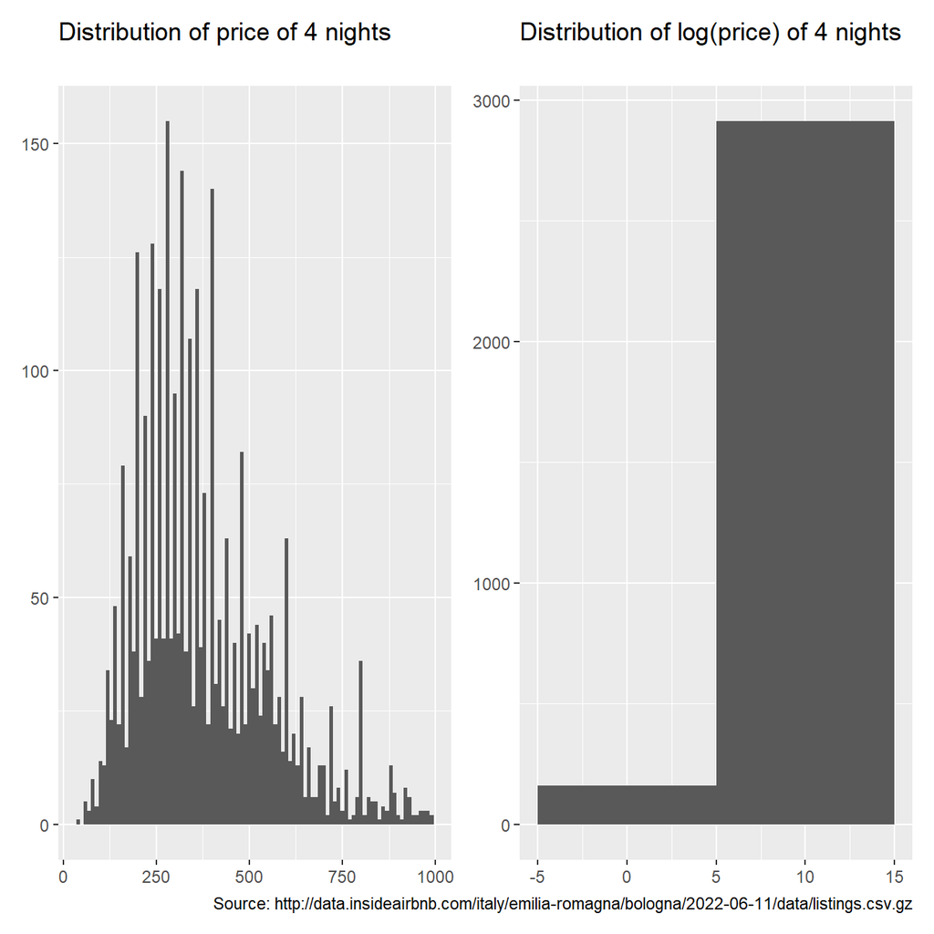

```r
g1 <- listings %>%
  filter(accommodates>1, price<250) %>%
  ggplot(aes(price_4_nights)) +
  geom_histogram(binwidth = 10) +
  labs(title = "Distribution of price of 4 nights",
        subtitle = "") +
  theme(plot.caption = element_text(hjust= 1),
        axis.title.x = element_blank(),
        axis.title.y = element_blank())

g2 <- listings %>%
  filter(accommodates>1, price<250) %>%
  ggplot(aes(log(price_4_nights))) +
  geom_histogram(binwidth = 10) +
  labs(title = "Distribution of log(price) of 4 nights",
        subtitle = "",
        caption = "Source: http://data.insideairbnb.com/italy/emilia-romagna/bologna/2022-06-11/data/listings.csv.gz") +
  theme(plot.caption = element_text(hjust= 1),
        axis.title.x = element_blank(),
        axis.title.y = element_blank())

g1+g2
```

*We will use the logarithmic scales thus we are interesting in quantifying the relative change of the price respect to other variables, and not its absolute value. In this way we can remedy the presence of many outliers.*

Fit a regression model called model1 with the following explanatory variables: prop_type_simplified, number_of_reviews, and review_scores_rating.

```r
model1 <- lm(log(price_4_nights) ~ prop_type_simplified +number_of_reviews + review_scores_rating, data = listings)
msummary(model1)
```

```
##                                                  Estimate Std. Error t value
## (Intercept)                                      6.233489   0.119631   52.11
## prop_type_simplifiedEntire rental unit          -0.019173   0.031950   -0.60
## prop_type_simplifiedOther                       -0.171623   0.038265   -4.49
## prop_type_simplifiedPrivate room in condo       -0.664070   0.051650  -12.86
## prop_type_simplifiedPrivate room in rental unit -0.650995   0.042112  -15.46
## number_of_reviews                               -0.001392   0.000139  -10.00
## review_scores_rating                            -0.029535   0.024617   -1.20
##                                                 Pr(>|t|)
## (Intercept)                                      < 2e-16 ***
## prop_type_simplifiedEntire rental unit              0.55
## prop_type_simplifiedOther                        7.6e-06 ***
## prop_type_simplifiedPrivate room in condo        < 2e-16 ***
## prop_type_simplifiedPrivate room in rental unit  < 2e-16 ***
## number_of_reviews                                < 2e-16 ***
## review_scores_rating                                0.23
##
## Residual standard error: 0.6 on 3084 degrees of freedom
##   (359 osservazioni eliminate a causa di valori mancanti)
## Multiple R-squared:  0.16,   Adjusted R-squared:  0.158
## F-statistic:   98 on 6 and 3084 DF,  p-value: <2e-16
```

*The total variability explained by this model is low (only 16%) then variables are not explanatory for cost for 4 nights.*

Interpret the coefficient review_scores_rating in terms of price_4_nights.

```r
model1a <- lm(log(price_4_nights) ~ review_scores_rating, data = listings)
msummary(model1a)
```

```
##                      Estimate Std. Error t value Pr(>|t|)
## (Intercept)            6.1445     0.1266   48.54   <2e-16 ***
## review_scores_rating  -0.0584     0.0267   -2.19    0.029 *
##
## Residual standard error: 0.654 on 3089 degrees of freedom
##   (359 osservazioni eliminate a causa di valori mancanti)
## Multiple R-squared:  0.00155,    Adjusted R-squared:  0.00123
## F-statistic: 4.79 on 1 and 3089 DF,  p-value: 0.0287
```

*t-stat value is greater than the 2% and p-value is less than 5% then we can reject the hypothesis of no difference between variables.*

*An extra review score rating decrease the logarithm of price by 0.06.*

*The total variability explained by this model is very low (only 0.1%) then scores of reviews is not a significant predictor for cost for 4 nights.*

Interpret the coefficient of prop_type_simplified in terms of price_4_nights.

```r
model1b <- lm(log(price_4_nights) ~ prop_type_simplified, data = listings)
msummary(model1b)
```

```
##                                                 Estimate Std. Error t value
## (Intercept)                                       6.0901     0.0273  223.00
## prop_type_simplifiedEntire rental unit           -0.0699     0.0314   -2.22
## prop_type_simplifiedOther                        -0.1879     0.0373   -5.03
## prop_type_simplifiedPrivate room in condo        -0.6807     0.0509  -13.36
## prop_type_simplifiedPrivate room in rental unit  -0.6798     0.0420  -16.19
##                                                 Pr(>|t|)
## (Intercept)                                      < 2e-16 ***
## prop_type_simplifiedEntire rental unit             0.026 *
## prop_type_simplifiedOther                        5.1e-07 ***
## prop_type_simplifiedPrivate room in condo        < 2e-16 ***
## prop_type_simplifiedPrivate room in rental unit  < 2e-16 ***
##
## Residual standard error: 0.636 on 3445 degrees of freedom
## Multiple R-squared:  0.121,  Adjusted R-squared:  0.12
## F-statistic:  118 on 4 and 3445 DF,  p-value: <2e-16
```

*t-stat value is greater than the 2% and p-value is less than 5% then we can reject the hypothesis of no difference between variables.*

*The total variability explained by this model is low (only 12%) then property types is not a significant predictor for cost for 4 nights.*

We want to determine if room_type is a significant predictor of the cost for 4 nights, given everything else in the model. Fit a regression model called model2 that includes all of the explanantory variables in model1 plus room_type.

```r
model2 <- lm(log(price_4_nights) ~ prop_type_simplified +number_of_reviews + review_scores_rating + room_type, data = listings)
msummary(model2)
```

```
##                                                  Estimate Std. Error t value
## (Intercept)                                      6.287806   0.116649   53.90
## prop_type_simplifiedEntire rental unit          -0.018218   0.031121   -0.59
## prop_type_simplifiedOther                        0.033786   0.046778    0.72
## prop_type_simplifiedPrivate room in condo       -0.315266   0.073679   -4.28
## prop_type_simplifiedPrivate room in rental unit -0.301693   0.067768   -4.45
## number_of_reviews                               -0.001447   0.000136  -10.64
## review_scores_rating                            -0.040568   0.024004   -1.69
## room_typeHotel room                              0.181025   0.107373    1.69
## room_typePrivate room                           -0.348557   0.053821   -6.48
## room_typeShared room                            -1.552696   0.133182  -11.66
##                                                 Pr(>|t|)
## (Intercept)                                      < 2e-16 ***
## prop_type_simplifiedEntire rental unit             0.558
## prop_type_simplifiedOther                          0.470
## prop_type_simplifiedPrivate room in condo        1.9e-05 ***
## prop_type_simplifiedPrivate room in rental unit  8.8e-06 ***
## number_of_reviews                                < 2e-16 ***
## review_scores_rating                               0.091 .
## room_typeHotel room                                0.092 .
## room_typePrivate room                            1.1e-10 ***
## room_typeShared room                             < 2e-16 ***
##
## Residual standard error: 0.585 on 3081 degrees of freedom
##   (359 osservazioni eliminate a causa di valori mancanti)
## Multiple R-squared:  0.204,  Adjusted R-squared:  0.202
## F-statistic: 87.7 on 9 and 3081 DF,  p-value: <2e-16
```

*The total variability explained by the model2 is better (20%) then model1 but remain very low so variables are not explanatory for cost for 4 nights.*

```r
model2a <- lm(log(price_4_nights) ~ room_type, data = listings)
msummary(model2a)
```

```
##                       Estimate Std. Error t value Pr(>|t|)
## (Intercept)             6.0414     0.0127  476.89   <2e-16 ***
## room_typeHotel room     0.3025     0.0981    3.08   0.0021 **
## room_typePrivate room  -0.5140     0.0245  -21.01   <2e-16 ***
## room_typeShared room   -1.3216     0.1293  -10.22   <2e-16 ***
##
## Residual standard error: 0.63 on 3446 degrees of freedom
## Multiple R-squared:  0.137,  Adjusted R-squared:  0.136
## F-statistic:  182 on 3 and 3446 DF,  p-value: <2e-16
```

*t-stat value is greater than the 2% and p-value is less than 5% then we can reject the hypothesis of no difference between variables.*

*The total variability explained by this model is low (only 14%) then property room is not a significant predictor for cost for 4 nights.*

## 1.5 Further variables/questions to explore on our own

Our dataset has many more variables, so here are some ideas on how you can extend your analysis

Are the number of bathrooms, bedrooms, beds, or size of the house (accomodates) significant predictors of price_4_nights?

```r
listings<-listings%>%
  separate(bathrooms_text,
           into = c("n_bathrooms", "text_bathrooms"),
           sep = 3)

listings<-listings%>%
  mutate(n_bathrooms=ifelse(test=n_bathrooms=="Hal",
                            yes="0.5",
                            no=n_bathrooms),
         n_bathrooms=ifelse(test=n_bathrooms=="Pri",
                            yes="0.5",
                            no=n_bathrooms),
  n_bathrooms = parse_number(n_bathrooms))

model3a <- lm(log(price_4_nights) ~ n_bathrooms, data = listings)
msummary(model3a)
```

```
##             Estimate Std. Error t value Pr(>|t|)
## (Intercept)   5.5727     0.0280   199.3   <2e-16 ***
## n_bathrooms   0.2816     0.0221    12.8   <2e-16 ***
##
## Residual standard error: 0.662 on 3443 degrees of freedom
##   (5 osservazioni eliminate a causa di valori mancanti)
## Multiple R-squared:  0.0451, Adjusted R-squared:  0.0449
## F-statistic:  163 on 1 and 3443 DF,  p-value: <2e-16
```

*t-stat value is greater than the 2% and p-value is less than 5% then we can reject the hypothesis of no difference between variables.*

*An extra bathroom increase the logarithm of price by 0.28.*

*The total variability explained by this model is very low (only 4.5%) then numbers of bathrooms are not a significant predictor for cost for 4 nights.*

```r
model3b <- lm(log(price_4_nights) ~ bedrooms, data = listings)
msummary(model3b)
```

```
##             Estimate Std. Error t value Pr(>|t|)
## (Intercept)   5.4999     0.0247   223.0   <2e-16 ***
## bedrooms      0.3062     0.0169    18.1   <2e-16 ***
##
## Residual standard error: 0.639 on 3293 degrees of freedom
##   (155 osservazioni eliminate a causa di valori mancanti)
## Multiple R-squared:  0.0906, Adjusted R-squared:  0.0903
## F-statistic:  328 on 1 and 3293 DF,  p-value: <2e-16
```

*t-stat value is greater than the 2% and p-value is less than 5% then we can reject the hypothesis of no difference between variables.*

*An extra bedroom increase the logarithm of the price by 0.31.*

```r
model3c <- lm(log(price_4_nights) ~ beds, data = listings)
msummary(model3c)
```

```
##             Estimate Std. Error t value Pr(>|t|)
## (Intercept)  5.62285    0.02044   275.1   <2e-16 ***
## beds         0.13669    0.00837    16.3   <2e-16 ***
##
## Residual standard error: 0.654 on 3411 degrees of freedom
##   (37 osservazioni eliminate a causa di valori mancanti)
## Multiple R-squared:  0.0725, Adjusted R-squared:  0.0722
## F-statistic:  267 on 1 and 3411 DF,  p-value: <2e-16
```

*t-stat value is greater than the 2% and p-value is less than 5% then we can reject the hypothesis of no difference between variables.*

*An extra bed increase the logarithm of the price by 0.14.*

```r
model3d <- lm(log(price_4_nights) ~ accommodates, data = listings)
msummary(model3d)
```

```
##              Estimate Std. Error t value Pr(>|t|)
## (Intercept)    5.3537     0.0238   224.5   <2e-16 ***
## accommodates   0.1638     0.0064    25.6   <2e-16 ***
##
## Residual standard error: 0.622 on 3448 degrees of freedom
## Multiple R-squared:  0.16,   Adjusted R-squared:  0.159
## F-statistic:  655 on 1 and 3448 DF,  p-value: <2e-16
```

*t-stat value is greater than the 2% and p-value is less than 5% then we can reject the hypothesis of no difference between variables.*

*An extra accommodates increase the logarithm of price by 0.16.*

Do superhosts (host_is_superhost) command a pricing premium, after controlling for other variables?

```r
listings%>%
  group_by(host_is_superhost)%>%
  summarise(avg_price=mean(price_4_nights))
```

| host_is_superhost | avg_price |
| --- | --- |
| FALSE | 586 |
| TRUE | 474 |

```r
model4 <- lm(log(price_4_nights) ~ host_is_superhost, data = listings)
msummary(model4)
```

```
##                       Estimate Std. Error t value Pr(>|t|)
## (Intercept)             5.8916     0.0138  428.36   <2e-16 ***
## host_is_superhostTRUE   0.0309     0.0253    1.22     0.22
##
## Residual standard error: 0.678 on 3448 degrees of freedom
## Multiple R-squared:  0.000431,   Adjusted R-squared:  0.000141
## F-statistic: 1.49 on 1 and 3448 DF,  p-value: 0.223
```

*The superhosts do not command a pricing premium: mean value of cost for 4 nights is higher for those who are not superhosts.*

*In addition t-stat value is lower than the 2% and p-value is above than 5% then we can accept the hypothesis of no difference between variables.*

*The condition of being a superhost increase the logarithm of the price of the room by 0.03 respect if the host is not a superhost.*

Determine whether location is a predictor of price_4_nights

```r
listings<-listings%>%
  mutate(neighbourhood_simplified=neighbourhood_cleansed)

model6 <- lm(log(price_4_nights) ~ neighbourhood_simplified, data = listings)
msummary(model6)
```

```
##                                                 Estimate Std. Error t value
## (Intercept)                                       5.6634     0.0540  104.88
## neighbourhood_simplifiedNavile                    0.1086     0.0635    1.71
## neighbourhood_simplifiedPorto - Saragozza         0.2945     0.0575    5.12
## neighbourhood_simplifiedSan Donato - San Vitale   0.1548     0.0629    2.46
## neighbourhood_simplifiedSanto Stefano             0.3304     0.0574    5.75
## neighbourhood_simplifiedSavena                   -0.1181     0.0774   -1.53
##                                                 Pr(>|t|)
## (Intercept)                                      < 2e-16 ***
## neighbourhood_simplifiedNavile                     0.087 .
## neighbourhood_simplifiedPorto - Saragozza        3.2e-07 ***
## neighbourhood_simplifiedSan Donato - San Vitale    0.014 *
## neighbourhood_simplifiedSanto Stefano            9.4e-09 ***
## neighbourhood_simplifiedSavena                     0.127
##
## Residual standard error: 0.668 on 3444 degrees of freedom
## Multiple R-squared:  0.0318, Adjusted R-squared:  0.0304
## F-statistic: 22.6 on 5 and 3444 DF,  p-value: <2e-16
```

*For some type of neighborhood (i.e., Porto - Saragozza, San Donato - San Vitale, Santo Stefano) t-stat value is greater than the 2% and p-value is less than 5% then we can reject the hypothesis of no difference between variables. For the other types of neighborhood (Navile, Savena), t-stat value is lower than the 2% and p-value is above 5% then we can accept the hypothesis of no difference between variables.*

## 1.6 Diagnostics, collinearity, summary tables

Check the residuals, using performance::check_model(model_x)

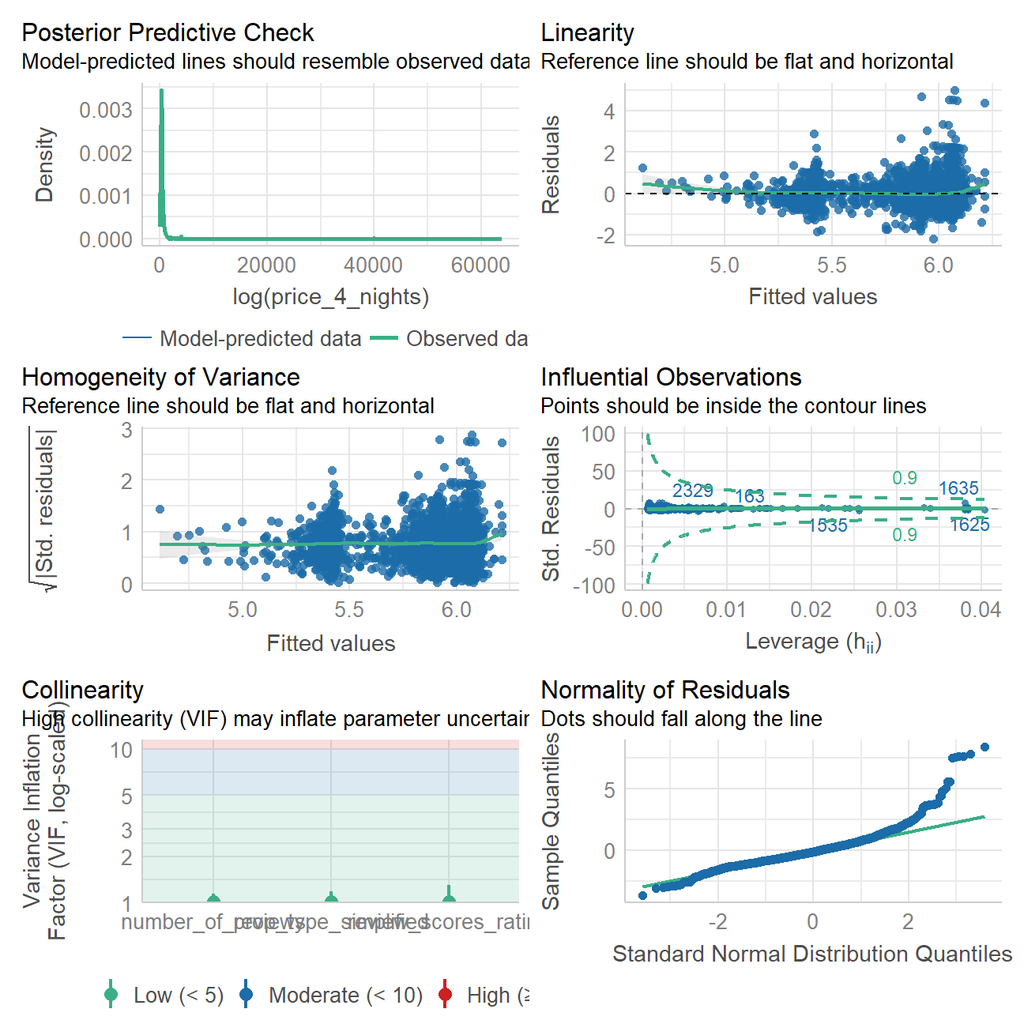

```r
check_model(model1)
```

```r
vif(model1)
```

```
##                      GVIF Df GVIF^(1/(2*Df))
## prop_type_simplified 1.01  4            1.00
## number_of_reviews    1.02  1            1.01
## review_scores_rating 1.01  1            1.01
```

*Model1 doesn’t suffer from collinearity*

As you start building models with more explanatory variables, make sure you use car::vif(model_x) to calculate the Variance Inflation Factor (VIF) for your predictors and determine whether you have colinear variables. A general guideline is that a VIF larger than 5 or 10 is large, and your model may suffer from collinearity. Remove the variable in question and run your model again without it.

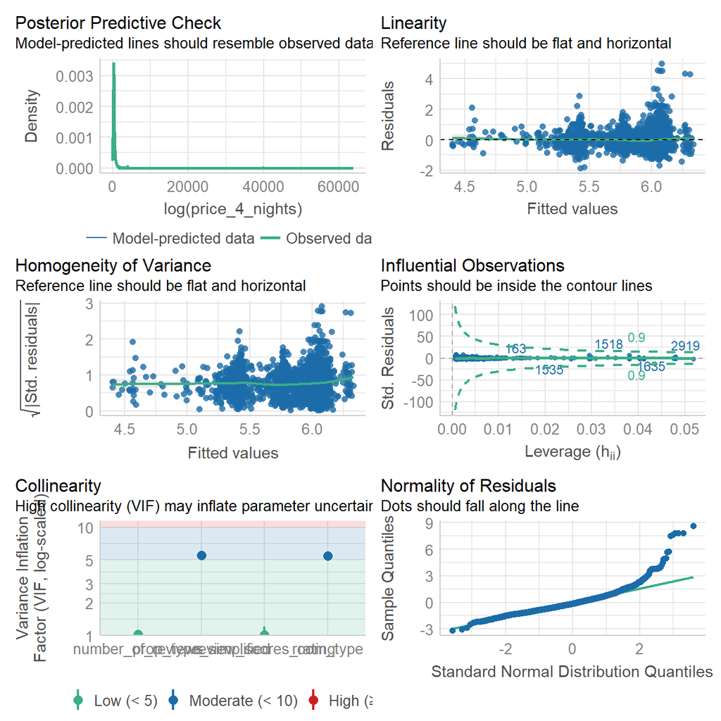

```r
check_model(model2)
```

```r
vif(model2)
```

```
##                      GVIF Df GVIF^(1/(2*Df))
## prop_type_simplified 5.48  4            1.24
## number_of_reviews    1.02  1            1.01
## review_scores_rating 1.01  1            1.01
## room_type            5.45  3            1.33
```

```r
model2b <- lm(log(price_4_nights) ~  number_of_reviews + review_scores_rating, data = listings)
msummary(model2b)
```

```
##                       Estimate Std. Error t value Pr(>|t|)
## (Intercept)           6.116204   0.125141   48.87   <2e-16 ***
## number_of_reviews    -0.001291   0.000149   -8.66   <2e-16 ***
## review_scores_rating -0.038931   0.026456   -1.47     0.14
##
## Residual standard error: 0.646 on 3088 degrees of freedom
##   (359 osservazioni eliminate a causa di valori mancanti)
## Multiple R-squared:  0.0252, Adjusted R-squared:  0.0246
## F-statistic: 39.9 on 2 and 3088 DF,  p-value: <2e-16
```

*Model2 suffer from collinearity(prop_type_simplified, room_type).* *We create a new model without the two variables*

Create a summary table, using huxtable (https://fda-bbs.netlify.app/example/modelling_side_by_side_tables/) that shows which models you worked on, which predictors are significant, the adjusted R2R2, and the Residual Standard Error.

```r
huxreg(list("Model1" = model1, "Model2b" = model2b),
       statistics = c('R squared' = 'r.squared',
                      'Adj. R squared' = 'adj.r.squared',
                      'Residual SE' = 'sigma'),
                 bold_signif = 0.05,
       stars = NULL) %>%
  set_caption('Comparison of models')
```

Comparison of models

|  | Model1 | Model2b |
| --- | --- | --- |
| (Intercept) | 6.233 | 6.116 |
|  | (0.120) | (0.125) |
| prop_type_simplifiedEntire rental unit | -0.019 |  |
|  | (0.032) |  |
| prop_type_simplifiedOther | -0.172 |  |
|  | (0.038) |  |
| prop_type_simplifiedPrivate room in condo | -0.664 |  |
|  | (0.052) |  |
| prop_type_simplifiedPrivate room in rental unit | -0.651 |  |
|  | (0.042) |  |
| number_of_reviews | -0.001 | -0.001 |
|  | (0.000) | (0.000) |
| review_scores_rating | -0.030 | -0.039 |
|  | (0.025) | (0.026) |
| R squared | 0.160 | 0.025 |
| Adj. R squared | 0.158 | 0.025 |
| Residual SE | 0.600 | 0.646 |

*The variables in bold denote level of significance*

## 1.7 Team members

### 1.7.1 Davide Mosezon

Born in Bologna in 1988 I’m a RFID Specialist in Lab ID Srl

### 1.7.2 Federica Mori

I am Italian, born in Mantova in 1986. I’ve working within innovation for more than 10 years. Now I’m an Innovation Manager at Confindustria Emilia-Romagna Ricerca.

### 1.7.3 Daniel Mota De Carvalho

I am Brazilian, and lived in different places there and Europe as well. My background is in marketing and sales have been working in FMCG companies for the last 20 years. Now I am challenging myself to learn business analytics and enter a new career path.

### 1.7.4 Virgínia Mendonça

I am Brazilian and have been living in EU the latest 10 years. I work with database management systems, most experienced in Sql Server and Postgres. Now adventuring myself in the data management world!